# اليوم الأول: مقدمة للغة R البرمجية، مع تنظيف البيانات وترتيبها

## 1. سنقوم بتهيئة بيئة العمل، ثم نحمّل الحزم البرمجية التي سنحتاج إليها أثناء هذه الورشة.

**library(maftools)**: حزمة قوية في لغة R مخصصة لتحليل بيانات Mutational Annotation Format (MAF) الخاصة بالتحليلات الجينومية (خصوصًا بيانات الطفرات الجسدية من تقنيات الـ NGS). تُستخدم الحزمة بكثرة في مجال المعلوماتية الحيوية (Bioinformatics) لتلخيص بيانات الطفرات، واستخراج إحصاءات، وإنشاء رسومات بيانية تفاعلية/استكشافية. للاطّلاع على التوثيق التفصيلي، يمكنك زيارة الرابط التالي:

👈 https://github.com/PoisonAlien/maftools

**library(ggplot2)**: يقوم هذا الأمر بتحميل الحزمة ggplot2، وهي نظام قوي ومرن لإنشاء رسوم بيانية ثابتة في لغة R. للاطّلاع على التوثيق التفصيلي، يمكنك زيارة الرابط التالي:

👈 https://ggplot2.tidyverse.org/

**library(skimr)**: حزمة مخصّصة لتوليد ملخصات وصفية سريعة وثرية للبيانات (summary statistics) بطريقة منظمة وسهلة القراءة.للاطّلاع على التوثيق التفصيلي، يمكنك زيارة الرابط التالي:

👈 https://docs.ropensci.org/skimr

**library(dplyr)**: زمة قوية ومستخدمة على نطاق واسع في لغة R لمعالجة البيانات (data manipulation).للاطّلاع على التوثيق التفصيلي، يمكنك زيارة الرابط التالي:

👈 https://dplyr.tidyverse.org

**library(tidyverse)**: تُحمِّل مجموعة متكاملة من الحزم المصممة لتسهيل تحليل البيانات في R.للاطّلاع على التوثيق التفصيلي، يمكنك زيارة الرابط التالي:

👈 https://www.tidyverse.org

### تثبيت الحزم البرمجية (خطوة اختيارية لمرة واحدة فقط)

> ⚠️ ملاحظة: هذه الخطوة مهمة فقط إذا لم تكن الحزم مثبتة مسبقًا على جهازك.  
> بعد التثبيت لمرة واحدة، يمكن تجاهلها والاكتفاء باستخدام `library()` لاحقًا.

```r
# تثبيت الحزم من CRAN
#install.packages("maftools")
#install.packages("dplyr")
#install.packages("skimr")
#install.packages("tidyverse")
#install.packages("ggplot2")

# إذا أردت تثبيت حزم من Bioconductor (لمجالات البيوانفورماتكس):
#if (!requireNamespace("BiocManager", quietly = TRUE))
#    install.packages("BiocManager")
#BiocManager::install("maftools")
```

```r
library(maftools)
library(dplyr)
library(skimr)
library(tidyverse)
```

```r
library(ggplot2)
```

📺 لمشاهدة شرح تثبيت الحزم من CRAN / GitHub / Bioconductor:  
[طريقة تثبيت الحزم في R](https://youtu.be/AQpDAl2yfLM?si=iGebpOznDkZOIlBS)

## 2. قراءة البيانات الوصفية (metadatat)، والتعرف عليها، ورسمها كملخصات

### 1️⃣ قراءة البيانات الوصفية والاكلينيكية:

**💡 ماذا نقصد بال Metadata؟ 🤔**  
البيانات الوصفية أو Metadata هي معلومات تصف البيانات نفسها وتساعدنا على فهم محتواها قبل التحليل.  
ببساطة، يمكن اعتبارها “بيانات عن البيانات”.

في سياق بيانات مرضى سرطان الثدي، تشمل البيانات الوصفية على سبيل المثال أعمدة مثل `gender` الذي يوضح جنس المريض، و `age_at_diagnosis` الذي يبين عمر المريض عند التشخيص، و `vital_status` الذي يعرض الحالة الحيوية للمريض سواء كان حيًا أو متوفى، و `pathologic_stage` الذي يوضح المرحلة المرضية للسرطان، و `histological_type` الذي يبين نوع الورم نسيجيًا.

الهدف من قراءة البيانات الوصفية هو معرفة معنى كل عمود قبل البدء بالتحليل، والتعرف على أنواع المتغيرات سواء كانت رقمية أو نصية أو تواريخ، وكذلك اكتشاف القيم المفقودة أو غير الصحيحة في البيانات.  
مثال توضيحي: إذا كانت لدينا قاعدة بيانات تحتوي على معلومات المرضى، فإن Metadata تخبرنا أن هذا العمود يمثل الجنس، وهذا العمود يمثل المرحلة المرضية، وهكذا.

```r
# قراءة البيانات من رابط خارجي
url <- "https://raw.githubusercontent.com/Dalah-Info/health-info-bioinformatics-r/refs/heads/main/metadata/breast_tumor_metadata.csv"
Breast_tumor_metadata <- read.csv(url)

# استكشاف البيانات عن طريق عرض أول 6 صفوف من البيانات
head(Breast_tumor_metadata)
```

|  | X | bcr_patient_uuid | bcr_patient_barcode | acronym | gender | vital_status | days_to_birth | days_to_death | days_to_last_followup | days_to_initial_pathologic_diagnosis | age_at_initial_pathologic_diagnosis | icd_10 | tissue_retrospective_collection_indicator | icd_o_3_histology | tissue_prospective_collection_indicator | history_of_neoadjuvant_treatment | icd_o_3_site | tumor_tissue_site | new_tumor_event_after_initial_treatment | radiation_therapy | race | project_code | prior_dx | disease_code | ethnicity | person_neoplasm_cancer_status | patient_id | year_of_initial_pathologic_diagnosis | histological_type | … |
| --- | --- | --- | --- | --- | --- | --- | --- | --- | --- | --- | --- | --- | --- | --- | --- | --- | --- | --- | --- | --- | --- | --- | --- | --- | --- | --- | --- | --- | --- | --- |
| 1 | 1 | 6E7D5EC6-A469-467C-B748-237353C23416 | TCGA-3C-AAAU | BRCA | FEMALE | Alive | -20211 | [Not Applicable] | 4047.0 | 0 | 55 | C50.9 | YES | 8520/3 | NO | No | C50.9 | Breast | NO | NO | WHITE | [Not Available] | No | [Not Available] | NOT HISPANIC OR LATINO | WITH TUMOR | AAAU | 2004 | Infiltrating Lobular Carcinoma | … |
| 2 | 2 | 55262FCB-1B01-4480-B322-36570430C917 | TCGA-3C-AALI | BRCA | FEMALE | Alive | -18538 | [Not Applicable] | 4005.0 | 0 | 50 | C50.9 | YES | 8500/3 | NO | No | C50.9 | Breast | NO | YES | BLACK OR AFRICAN AMERICAN | [Not Available] | No | [Not Available] | NOT HISPANIC OR LATINO | TUMOR FREE | AALI | 2003 | Infiltrating Ductal Carcinoma | … |
| 3 | 3 | 427D0648-3F77-4FFC-B52C-89855426D647 | TCGA-3C-AALJ | BRCA | FEMALE | Alive | -22848 | [Not Applicable] | 1474.0 | 0 | 62 | C50.9 | YES | 8500/3 | NO | No | C50.9 | Breast | NO | NO | BLACK OR AFRICAN AMERICAN | [Not Available] | No | [Not Available] | NOT HISPANIC OR LATINO | TUMOR FREE | AALJ | 2011 | Infiltrating Ductal Carcinoma | … |
| 4 | 4 | C31900A4-5DCD-4022-97AC-638E86E889E4 | TCGA-3C-AALK | BRCA | FEMALE | Alive | -19074 | [Not Applicable] | 1448.0 | 0 | 52 | C50.9 | YES | 8500/3 | NO | No | C50.9 | Breast | NO | NO | BLACK OR AFRICAN AMERICAN | [Not Available] | No | [Not Available] | NOT HISPANIC OR LATINO | TUMOR FREE | AALK | 2011 | Infiltrating Ductal Carcinoma | … |
| 5 | 5 | 6623FC5E-00BE-4476-967A-CBD55F676EA6 | TCGA-4H-AAAK | BRCA | FEMALE | Alive | -18371 | [Not Applicable] | 348.0 | 0 | 50 | C50.9 | NO | 8520/3 | YES | No | C50.9 | Breast | NO | NO | WHITE | [Not Available] | No | [Not Available] | NOT HISPANIC OR LATINO | TUMOR FREE | AAAK | 2013 | Infiltrating Lobular Carcinoma | … |
| 6 | 6 | 86C6F993-327F-4525-9983-29C55625593A | TCGA-5L-AAT0 | BRCA | FEMALE | Alive | -15393 | [Not Applicable] | 1477 | 0 | 42 | C50.9 | YES | 8520/3 | NO | No | C50.9 | Breast | NO | YES | WHITE | [Not Available] | Yes | [Not Available] | HISPANIC OR LATINO | TUMOR FREE | AAT0 | 2010 | Infiltrating Lobular Carcinoma | … |

### 2️⃣ معرفة عدد الأعمدة والصفوف، حيث:

**الأعمدة:** عدد البيانات الوصفية والاكلينية التي تم جمعها.  
**الصفوف:** عدد المرضى.

```r
# حساب عدد الأعمدة (عدد المتغيرات أو الخصائص التي لدينا عن المرضى)
print(paste("Number of clinical data:", ncol(Breast_tumor_metadata)))
```

```
## [1] "Number of clinical data: 51"
```

```r
# حساب عدد الصفوف (عدد المرضى في قاعدة البيانات)
print(paste("Number of patients:", nrow(Breast_tumor_metadata)))
```

```
## [1] "Number of patients: 1099"
```

📺 لمراجعة الأساسيات وأنواع البيانات والمتغيرات في R:  
[أنواع البيانات والمتغيرات في R](https://youtu.be/0ZL5iVWh0rc?si=HnFczVmCaSIV3NFD)

### 3️⃣ تنظيف البيانات

سنقوم بقراءة جميع الأعمدة وتلخيصها، وذلك بهدف تحديد الأعمدة التي ينبغي إزالتها، مثل:

- الأعمدة التي تحتوي على بيانات مفقودة بنسبة تتجاوز 50% (قد تكون القيم المفقودة مسجّلة كمسافة بيضاء، أو NA، أو فارغة).
- الأعمدة غير المفيدة للتحليل، مثل أعمدة تاريخ الإدخال أو التسجيل.
- الأعمدة التي تحتوي على قيمة واحدة مكررة لجميع المرضى.

لاكتشاف هذه الحالات بسهولة، سنستخدم حزمة **skimr** التي توفّر ملخصًا شاملًا لكل عمود في ملف البيانات، مما يساعد على تحديد الأعمدة الفارغة أو غير المهمة.

```r
skimr::skim(Breast_tumor_metadata)
```

Data summary

| Name | Breast_tumor_metadata |
| --- | --- |
| Number of rows | 1099 |
| Number of columns | 51 |
| _______________________ |  |
| Column type frequency: |  |
| character | 44 |
| logical | 4 |
| numeric | 3 |
| ________________________ |  |
| Group variables | None |

**Variable type: character**

| skim_variable | n_missing | complete_rate | min | max | empty | n_unique | whitespace |
| --- | --- | --- | --- | --- | --- | --- | --- |
| bcr_patient_uuid | 0 | 1 | 36 | 36 | 0 | 1099 | 0 |
| bcr_patient_barcode | 0 | 1 | 12 | 12 | 0 | 1099 | 0 |
| acronym | 0 | 1 | 4 | 4 | 0 | 1 | 0 |
| gender | 0 | 1 | 4 | 6 | 0 | 2 | 0 |
| vital_status | 0 | 1 | 4 | 5 | 0 | 2 | 0 |
| days_to_birth | 0 | 1 | 5 | 15 | 0 | 1048 | 0 |
| days_to_death | 0 | 1 | 3 | 16 | 0 | 150 | 0 |
| days_to_last_followup | 0 | 1 | 1 | 15 | 0 | 777 | 0 |
| icd_10 | 0 | 1 | 5 | 7 | 0 | 7 | 0 |
| tissue_retrospective_collection_indicator | 0 | 1 | 2 | 15 | 0 | 3 | 0 |
| icd_o_3_histology | 0 | 1 | 6 | 6 | 0 | 22 | 0 |
| tissue_prospective_collection_indicator | 0 | 1 | 2 | 15 | 0 | 3 | 0 |
| history_of_neoadjuvant_treatment | 0 | 1 | 2 | 15 | 0 | 3 | 0 |
| icd_o_3_site | 0 | 1 | 5 | 5 | 0 | 6 | 0 |
| tumor_tissue_site | 0 | 1 | 6 | 6 | 0 | 1 | 0 |
| new_tumor_event_after_initial_treatment | 0 | 1 | 2 | 15 | 0 | 4 | 0 |
| radiation_therapy | 0 | 1 | 2 | 15 | 0 | 5 | 0 |
| race | 0 | 1 | 5 | 32 | 0 | 6 | 0 |
| project_code | 0 | 1 | 4 | 15 | 0 | 2 | 0 |
| prior_dx | 0 | 1 | 2 | 13 | 0 | 3 | 0 |
| disease_code | 0 | 1 | 4 | 15 | 0 | 2 | 0 |
| ethnicity | 0 | 1 | 9 | 22 | 0 | 5 | 0 |
| person_neoplasm_cancer_status | 0 | 1 | 9 | 15 | 0 | 4 | 0 |
| patient_id | 0 | 1 | 4 | 4 | 0 | 1099 | 0 |
| year_of_initial_pathologic_diagnosis | 0 | 1 | 4 | 15 | 0 | 27 | 0 |
| histological_type | 0 | 1 | 14 | 32 | 0 | 9 | 0 |
| tissue_source_site | 0 | 1 | 2 | 2 | 0 | 40 | 0 |
| form_completion_date | 0 | 1 | 8 | 10 | 0 | 315 | 0 |
| pathologic_T | 0 | 1 | 2 | 3 | 0 | 13 | 0 |
| pathologic_M | 0 | 1 | 2 | 8 | 0 | 4 | 0 |
| clinical_M | 0 | 1 | 16 | 16 | 0 | 1 | 0 |
| pathologic_N | 0 | 1 | 2 | 9 | 0 | 16 | 0 |
| system_version | 0 | 1 | 3 | 15 | 0 | 6 | 0 |
| pathologic_stage | 0 | 1 | 7 | 15 | 0 | 13 | 0 |
| clinical_stage | 0 | 1 | 16 | 16 | 0 | 1 | 0 |
| clinical_T | 0 | 1 | 15 | 15 | 0 | 1 | 0 |
| clinical_N | 0 | 1 | 16 | 16 | 0 | 1 | 0 |
| extranodal_involvement | 0 | 1 | 16 | 16 | 0 | 1 | 0 |
| postoperative_rx_tx | 0 | 1 | 2 | 15 | 0 | 4 | 0 |
| lymph_node_examined_count | 0 | 1 | 1 | 15 | 0 | 43 | 0 |
| primary_lymph_node_presentation_assessment | 0 | 1 | 2 | 15 | 0 | 4 | 0 |
| initial_pathologic_diagnosis_method | 0 | 1 | 13 | 43 | 0 | 9 | 0 |
| number_of_lymphnodes_positive_by_he | 0 | 1 | 1 | 15 | 0 | 32 | 0 |
| anatomic_neoplasm_subdivision | 0 | 1 | 4 | 113 | 0 | 53 | 0 |

**Variable type: logical**

| skim_variable | n_missing | complete_rate | mean | count |
| --- | --- | --- | --- | --- |
| primary_therapy_outcome_success | 1099 | 0 | NaN | : |
| eastern_cancer_oncology_group | 1099 | 0 | NaN | : |
| residual_tumor | 1099 | 0 | NaN | : |
| tumor_thickness | 1099 | 0 | NaN | : |

**Variable type: numeric**

| skim_variable | n_missing | complete_rate | mean | sd | p0 | p25 | p50 | p75 | p100 | hist |
| --- | --- | --- | --- | --- | --- | --- | --- | --- | --- | --- |
| X | 0 | 1 | 550.00 | 317.40 | 1 | 275.5 | 550 | 824.5 | 1099 | ▇▇▇▇▇ |
| days_to_initial_pathologic_diagnosis | 0 | 1 | 0.00 | 0.00 | 0 | 0.0 | 0 | 0.0 | 0 | ▁▁▇▁▁ |
| age_at_initial_pathologic_diagnosis | 0 | 1 | 58.43 | 13.22 | 26 | 49.0 | 58 | 67.0 | 90 | ▁▆▇▅▂ |

نقوم الآن بإزالة الأعمدة ذات الإشكال لنركز على الأعمدة المهمة فقط.

```r
# أعمدة لا تحتوي على قيم
Breast_tumor_metadata$primary_therapy_outcome_success <- NULL
Breast_tumor_metadata$eastern_cancer_oncology_group <- NULL
Breast_tumor_metadata$residual_tumor <- NULL
Breast_tumor_metadata$tumor_thickness <- NULL

#عمود يحتوي على قيمة واحدة فقط لكل المرضي (لا يعطي أي معلومة)
Breast_tumor_metadata$days_to_initial_pathologic_diagnosis <- NULL
```

عدد الأعمدة الوصفية بعد إزالة الأعمدة غير المهمة:

```r
# عرض عدد الأعمدة المتبقية بعد إزالة الأعمدة غير المفيدة
print(paste("Number of clinical data:", ncol(Breast_tumor_metadata)))
```

```
## [1] "Number of clinical data: 46"
```

نقرأ أسماء الأعمدة ونسكتشف ونرسم بعضها:

```r
# عرض أسماء الأعمدة الموجودة في البيانات بعد التنظيف
colnames(Breast_tumor_metadata)
```

```
##  [1] "X"
##  [2] "bcr_patient_uuid"
##  [3] "bcr_patient_barcode"
##  [4] "acronym"
##  [5] "gender"
##  [6] "vital_status"
##  [7] "days_to_birth"
##  [8] "days_to_death"
##  [9] "days_to_last_followup"
## [10] "age_at_initial_pathologic_diagnosis"
## [11] "icd_10"
## [12] "tissue_retrospective_collection_indicator"
## [13] "icd_o_3_histology"
## [14] "tissue_prospective_collection_indicator"
## [15] "history_of_neoadjuvant_treatment"
```

[output cut: 31 more lines]

🔵 Gender information (الجنس):  
العمود: gender

الهدف: معرفة توزيع المرضى حسب الجنس (ذكر/أنثى).

السبب: بعض أنواع السرطان (مثل سرطان الثدي) تختلف بشكل كبير بين الجنسين.

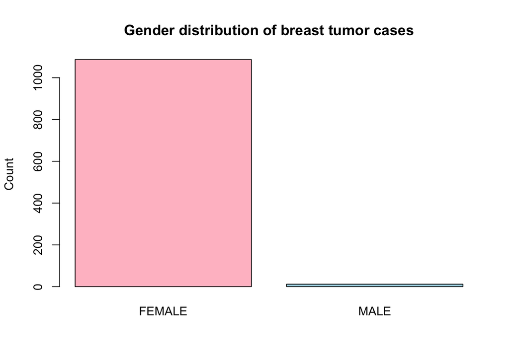

```r
# إنشاء جدول لعدد المرضى حسب الجنس
table_gender <- table(Breast_tumor_metadata$gender)

# رسم بياني يوضح توزيع الجنس
barplot(table_gender,
        main = "Gender distribution of breast tumor cases", # عنوان الرسم
        ylab = "Count",                                     # تسمية المحور الرأسي
        col = c("pink", "lightblue"))                       # ألوان للأعمدة
```

🔵 Vital status information (الحالة الحيوية):  
العمود: vital_status

الهدف: معرفة عدد المرضى الأحياء مقابل المتوفين.

السبب: يساعد على فهم النتائج السريرية وربطها بالعوامل الأخرى.

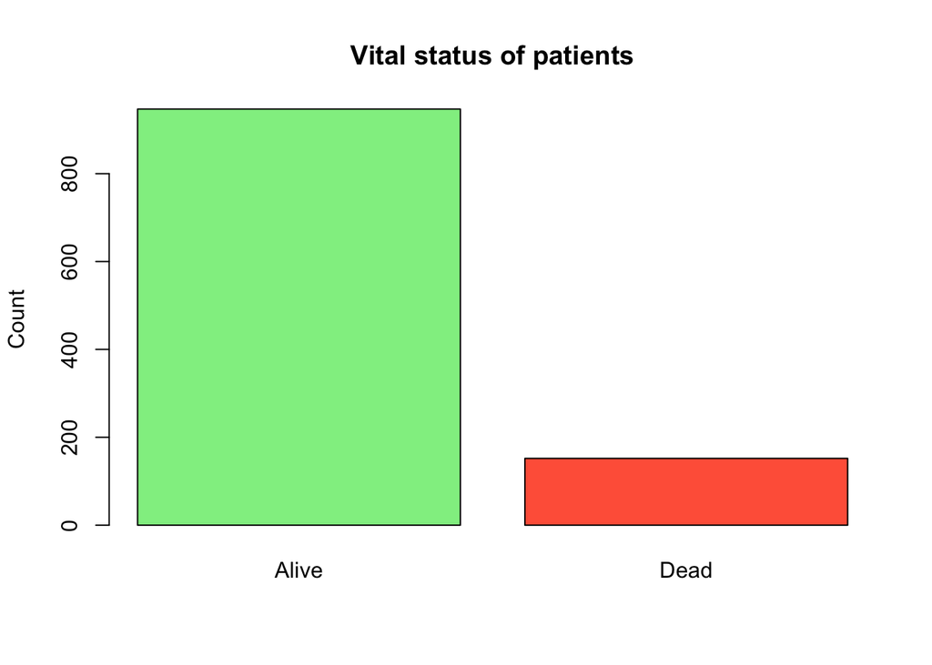

```r
# إنشاء جدول  لعدد المرضى حسب الحالة الحيوية (حي أو متوفى)
table_vital_status <- table(Breast_tumor_metadata$vital_status)

# رسم بياني يوضح عدد المرضى الأحياء مقابل المتوفين
barplot(table_vital_status,
        main = "Vital status of patients",# عنوان الرسم
        ylab = "Count",                   # تسمية المحور الرأسي (عدد المرضى)
        col = c("lightgreen", "tomato"))  # أخضر = حي، أحمر = متوفى
```

🔵 New tumor events after treatment information (ظهور ورم جديد بعد العلاج):  
العمود: new_tumor_event_after_initial_treatment

الهدف: معرفة عدد الحالات التي ظهر لديها ورم جديد بعد العلاج الأولي.

السبب: هذا المؤشر مهم لفهم الاستجابة للعلاج وتقييم احتمالية الانتكاس.

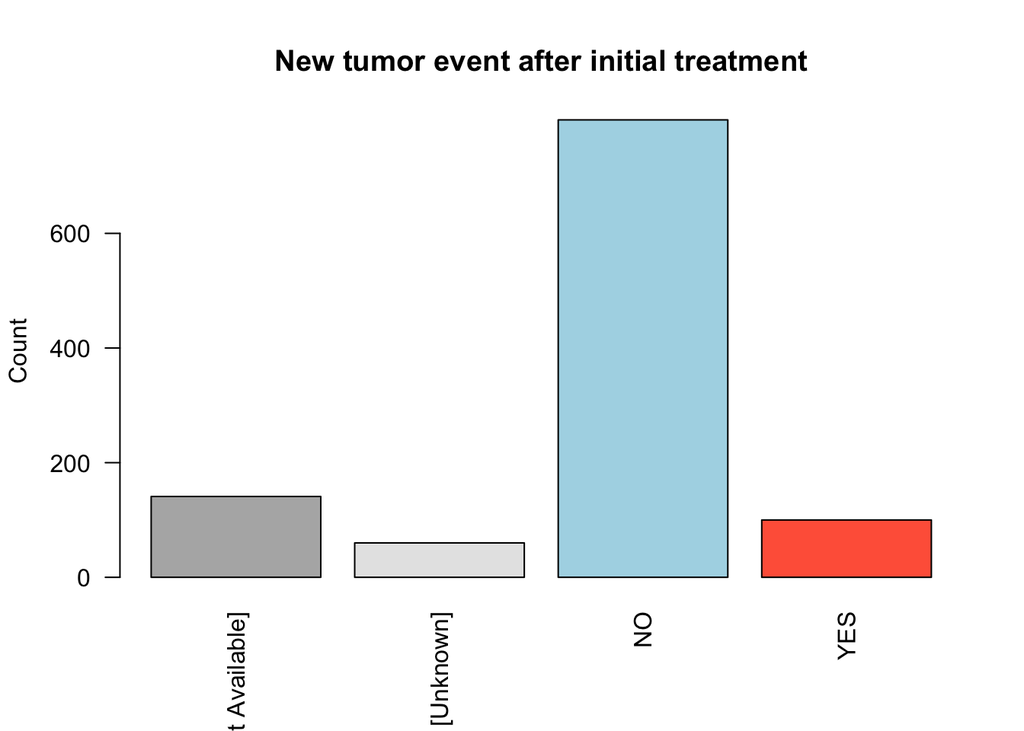

```r
# إنشاء جدول لعدد الحالات التي ظهر لديها ورم جديد بعد العلاج الأولي
table_event <- table(Breast_tumor_metadata$new_tumor_event_after_initial_treatment)

# رسم بياني يوضح عدد الحالات مع/بدون ورم جديد
barplot(table_event,
        main = "New tumor event after initial treatment",   # عنوان الرسم
        ylab = "Count",                                     # تسمية المحور الرأسي
        col = c("gray70", "gray90", "lightblue", "tomato"), # ألوان للأعمدة
        las = 2)                                           # تدوير أسماء التصنيفات لسهولة القراءة
```

🔵 Radiation therapy status (العلاج الإشعاعي):  
العمود: radiation_therapy

الهدف: معرفة نسبة المرضى الذين تلقوا علاج إشعاعي.

السبب: العلاج الإشعاعي عنصر مهم في خطة العلاج وقد يؤثر على النتائج.

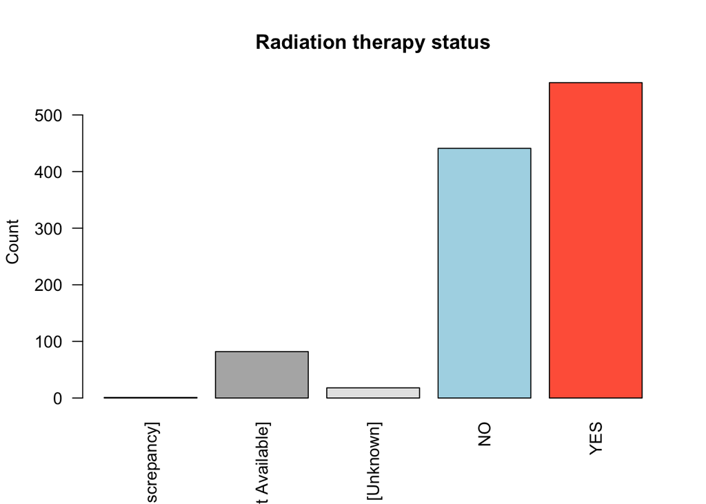

```r
# إنشاء جدول  يوضح عدد المرضى الذين تلقوا/لم يتلقوا علاج إشعاعي
table_radiation <- table(Breast_tumor_metadata$radiation_therapy)

# رسم بياني يوضح حالة العلاج الإشعاعي
barplot(table_radiation,
        main = "Radiation therapy status",                             # عنوان الرسم
        ylab = "Count",                                                # تسمية المحور الرأسي
        col = c("orange", "gray70", "gray90", "lightblue", "tomato"),  # ألوان مختلفة للتصنيفات
        las = 2)                                                       # تدوير النصوص لسهولة القراءة
```

🔵 Histological types of breast tumors (الأنواع النسيجية للأورام):  
العمود: histological_type

الهدف: معرفة الأنواع النسيجية المختلفة لأورام الثدي.

السبب: يساعد في تصنيف المرضى حسب نوع الورم، وهو مهم جدًا في التشخيص والعلاج.

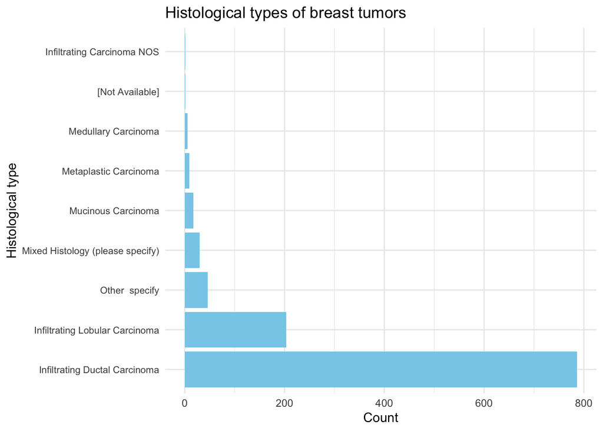

```r
# إنشاء جدول للأنواع النسيجية المختلفة للأورام
# مع ترتيبها تنازليًا (الأكثر شيوعًا أولًا)
table_hist <- sort(table(Breast_tumor_metadata$histological_type), decreasing = TRUE)

# تحويل الجدول إلى إطار بيانات (DataFrame) حتى نستطيع استخدام ggplot
df_hist <- as.data.frame(table_hist)

# رسم بياني باستخدام ggplot يوضح الأنواع النسيجية للأورام
ggplot(df_hist, aes(x = Var1, y = Freq)) +            #x = أسماء الأنواع النسيجية، y = عدد الحالات لكل نوع
  geom_col(fill = "skyblue") +                        # أعمدة ملونة باللون الأزرق
  coord_flip() +                                      # قلب الرسم (الأعمدة أفقية بدل رأسية)
  labs(title = "Histological types of breast tumors", # عنوان الرسم
       x = "Histological type", y = "Count") +        # تسمية المحور الرأسي و الأفقي
  theme_minimal() +                                   # شكل مبسط (ثيم) للرسم
  theme(axis.text.y = element_text(size = 8))         # تصغير حجم النص على المحور
```

🔵 Pathological stage of breast tumors (المرحلة المرضية للورم):  
العمود: pathologic_stage

الهدف: توزيع المرضى حسب مراحل السرطان (Stage I, II, III, IV).

السبب: المرحلة المرضية مؤشر مهم جدًا للتشخيص والتنبؤ بالنتائج وخطة العلاج.

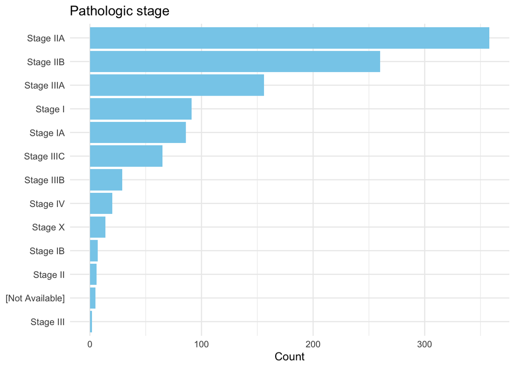

```r
# إنشاء جدول لمراحل السرطان (Stage I, II, III, IV)
# مع ترتيبها تنازليًا (الأكثر شيوعًا أولًا)
table_stage <- sort(table(Breast_tumor_metadata$pathologic_stage), decreasing = TRUE)

# تحويل الجدول إلى إطار بيانات
df_stage <- as.data.frame(table_stage)

# إعادة تسمية الأعمدة لتكون أوضح
names(df_stage) <- c("Stage","Count")

# رسم بياني باستخدام ggplot يوضح توزيع المرضى حسب المرحلة المرضية
ggplot(df_stage, aes(x = reorder(Stage, Count), y = Count)) +  #x = ترتيب المراحل حسب عدد المرضى | y =  عدد المرضى في كل مرحلة
  geom_col(fill = "skyblue") +                                # أعمدة ملونة باللون الأزرق
  coord_flip() +                                              # قلب الرسم (الأعمدة أفقية)
  labs(title = "Pathologic stage", x = NULL, y = "Count") +   # عنوان الرسم وتسمية المحاور
  theme_minimal() +                                           # شكل مبسط (ثيم) للرسم
  theme(axis.text.y = element_text(size = 9))                 # حجم النص على المحور
```

📺 لفهم ggplot2 وكيفية إنشاء الرسوم:  
[الرسوم البيانية باستخدام ggplot](https://youtu.be/5fh-XZ75ouE?si=8QXyj9e7sZoGCMML)

## 3. حفظ الملف بعد الانتهاء منه

```r
write.csv(Breast_tumor_metadata, "Breast_tumor_metadata_cleaned.csv")
```